# CS 422 Homework 3

George Tapia (A20450857)

2023-02-12

### Part 2.1

```r
#install.packages('ISRL')

#Here, we are splitting the data set into two parts, one is the training set, the other is the test set
#We generally split our data set into two parts so that we can train our model on the greater portion,
#and evaluate its performance on the test data set (the smaller portion)
#Some recommended splits for large data sets are 90/10 and 95/5
#Some recommended splits for small data sets are 70/30 and 80/20
library(ISLR)
set.seed(1122)
index <- sample(1:nrow(Auto), 0.95*dim(Auto)[1])
train.df <- Auto[index,]
test.df <- Auto[-index,]
```

### Part 2.1-A

```r
library(psych)
#library(lessR)

#creating a model using all predictors except name
#Dependent variable -> mpg
#Independent variables -> cylinders, displacement, horsepower, weight, acceleration, year, origin
#Function reads as "generate a linear regression model using mpg as the dependent/response variable and
#all other variables in the data set as predictors except name"
linear_regression_model <- lm(mpg ~ . - name, data = train.df)
print(linear_regression_model)
```

```
##
## Call:
## lm(formula = mpg ~ . - name, data = train.df)
##
## Coefficients:
##  (Intercept)     cylinders  displacement    horsepower        weight
##   -16.598211     -0.523480      0.020422     -0.017497     -0.006416
## acceleration          year        origin
##     0.087418      0.738273      1.516023
```

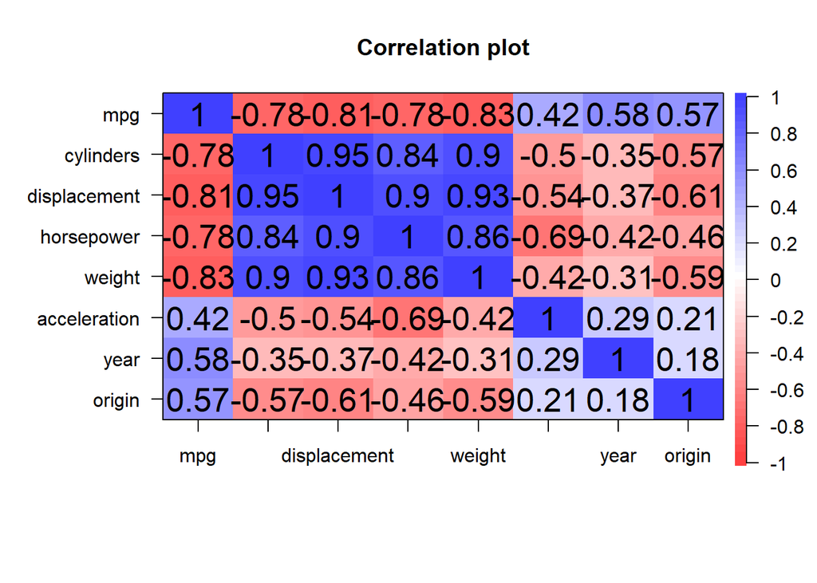

```r
# ^         y-intercept
# Y = -16.59821 + -0.52348(cylinders) + 0.02042(displacement) + -0.01750(horsepower) + -0.00642(weight) + 0.08742(acceleration) + 0.73827(year) + 1.51602(origin)


auto_subset <- subset(Auto, select=-name)
correlation_matrix <- cor(auto_subset, Auto$mpg)

cor.plot(auto_subset)
```

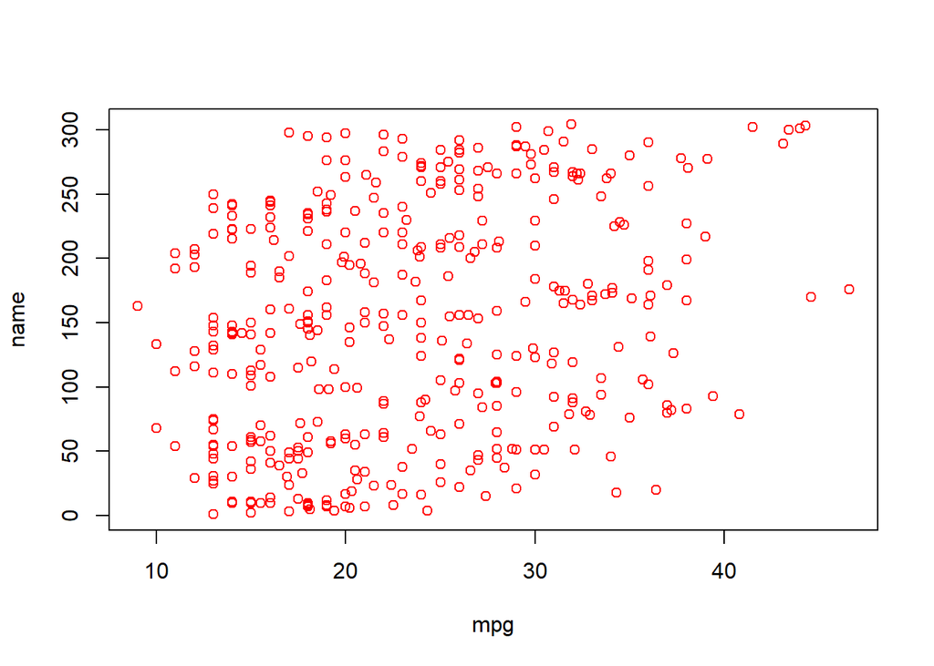

```r
plot(Auto$mpg, Auto$name, ylab = 'name', xlab = 'mpg', col='red')
```

```r
# plot(linear_regression_model)
```

### Part 2.1-I

#### Why is using name as a predictor not a reasonable thing to do? Using the name predictor is not a reasonable thing to do since the name will not provide any useful information for our model. The name attribute is unique so we can’t generate any useful pattern from it. The variables that are likely to contribute to our model will be the other values given that we can derive a pattern from them, and they all have some sort of relationship to the mpg(correlation plot shows it). Also, if we look at the scatter plot between name and mpg, we can see that this is a noisy graph, there is no relationship between name and mpg.

### Part 2-II

```r
print(summary(linear_regression_model))
```

```
##
## Call:
## lm(formula = mpg ~ . - name, data = train.df)
##
## Residuals:
##     Min      1Q  Median      3Q     Max
## -9.6805 -2.1786 -0.0977  1.9180 13.0364
##
## Coefficients:
##                Estimate Std. Error t value Pr(>|t|)
## (Intercept)  -1.660e+01  4.780e+00  -3.472 0.000578 ***
## cylinders    -5.235e-01  3.340e-01  -1.567 0.117947
## displacement  2.042e-02  7.760e-03   2.632 0.008857 **
## horsepower   -1.750e-02  1.424e-02  -1.229 0.219908
## weight       -6.416e-03  6.785e-04  -9.457  < 2e-16 ***
## acceleration  8.742e-02  1.031e-01   0.848 0.396859
## year          7.383e-01  5.259e-02  14.039  < 2e-16 ***
## origin        1.516e+00  2.893e-01   5.240 2.73e-07 ***
## ---
## Signif. codes:  0 '***' 0.001 '**' 0.01 '*' 0.05 '.' 0.1 ' ' 1
##
## Residual standard error: 3.367 on 364 degrees of freedom
## Multiple R-squared:  0.817,  Adjusted R-squared:  0.8135
## F-statistic: 232.2 on 7 and 364 DF,  p-value: < 2.2e-16
```

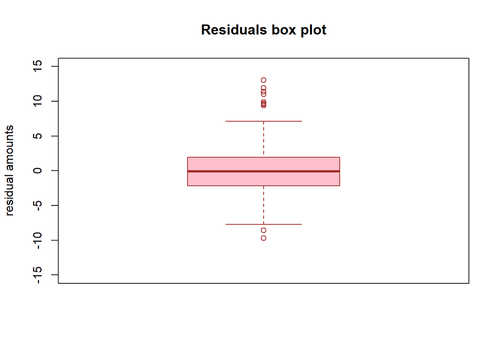

```r
boxplot(linear_regression_model$residuals,
        col ='pink',
        border = 'brown',
        ylim= c(-15,15),
        main = "Residuals box plot", ylab = "residual amounts",
        labels = c("1st Quarter: X", "Median: Y", "3rd Quarter: Z"))
```

```r
#min -> minimum amount that y hat deviates from the actual y is -9.680 below the actual mpg
#1Q -> 25% of the residuals are below -2.179
#median -> 50% of the residuals are below -0.098
#3Q -> 75% of the residuals are below 1.918
#max -> the maximum amount that y hat deviates from the actual y is 13.036 over the actual mpg

#number of predictors
p <- 7
#number of observations
n <- nrow(train.df)

#hint was definitely taken into account
R_squared <- summary(linear_regression_model)$r.squared
Adj_R_squared <- summary(linear_regression_model)$adj.r.squared

RSS <- sum(resid(linear_regression_model)^2)
RSE <- sqrt(RSS/(n-p-1))
RMSE <- sqrt(RSS/n)
mean_mpg <- mean(Auto$mpg)
percentage_error = round(RSE/mean_mpg * 100, 2)


cat("R-sq value is", round(R_squared, 2), "\n",
    "Adjusted R-sq value is", round(Adj_R_squared, 2), "\n",
    "RSE is", round(RSE, 2), "\n",
    "RMSE is", round(RMSE, 2), "\n",
    "Percentage error of RSE is", paste0(percentage_error, "%"), "\n\n")
```

```
## R-sq value is 0.82
##  Adjusted R-sq value is 0.81
##  RSE is 3.37
##  RMSE is 3.33
##  Percentage error of RSE is 14.36%
```

```r
cat("All the confidence intervals below, we are 95% confident each of the predictors slope is within each range specified", '\n')
```

```
## All the confidence intervals below, we are 95% confident each of the predictors slope is within each range specified
```

```r
confint(linear_regression_model, conf.level=0.95)
```

```
##                      2.5 %       97.5 %
## (Intercept)  -25.998365961 -7.198055943
## cylinders     -1.180354581  0.133393984
## displacement   0.005161941  0.035682303
## horsepower    -0.045495962  0.010502167
## weight        -0.007750366 -0.005081879
## acceleration  -0.115245185  0.290081454
## year           0.634857599  0.841688850
## origin         0.947071647  2.084973875
```

#### Since the adjusted R^2 value is close to one (R^2=0.81), this means that roughly 81% of the variance is accounted for by the model. Roughly 19% cannot be explained by the model, which is a relatively small amount. In terms of RSE and RSME, these pretty much tell us a similar thing. The RSE tells us the average amount that the models predictions deviate from the mpg values, while the RSME tells us the average magnitude of the errors. Since, the percentage error relative to the mean mpg is small (14%), this is a small margin of error, and thus, still a good model, in terms of all the variables(R^2, RSE, RSME) values.